```python
# utils
import numpy as np
import matplotlib.pyplot as plt
import pandas as pd
import seaborn as sns

import time
from tqdm import tqdm
from sklearn.neighbors import KNeighborsClassifier
from sklearn.svm import SVC
from sklearn.linear_model import LogisticRegression
from sklearn.naive_bayes import GaussianNB
from sklearn.tree import DecisionTreeClassifier
from sklearn.ensemble import (RandomForestClassifier,
                              GradientBoostingClassifier)
from sklearn.model_selection import train_test_split, KFold, StratifiedKFold

plt.rcParams.update({'font.size': 16})
plt.rcParams["legend.markerscale"] = 1
import warnings
warnings.filterwarnings("ignore")
```

[output not shown]

```python
from imblearn.over_sampling import SMOTE
from collections import Counter
from sklearn.preprocessing import LabelEncoder

from multi_imbalance.utils.metrics import gmean_score
from sklearn.metrics import make_scorer
from sklearn.model_selection import KFold #for K-fold cross validation
from sklearn.model_selection import cross_val_score #score evaluation
from sklearn.metrics import confusion_matrix #for confusion matrix
```

# SOUP: A new approach in handling Imbalanced Multi-class problems

## Highlights

- Safety coefficients can be efficiently exploited in resampling techniques to improve classifiers.
- SOUP looks at the complex relations between classes and proposed a dataset with reasonable size.
- SOUP works significantly better than SMOTE if samples from different classes are overlapping.

## Background

Up to now many specialized methods for improving the classification of imbalanced data have been introduced. However, most of the current research concerns binary classification problems. Moreover, multiclass imbalanced classification problems are more difficult than their binary counterparts. The most well-known resampling technique for imbalanced multi-class problems is SMOTE, which stands for Synthetic Minority Over-sampling TEchnique. SMOTE is an oversampling approach that creates synthetic minority class samples.

However, class imbalances are often accompanied by data difficulty factors. Factors include the overlapping between the classes or the presence of many minority class examples inside the majority class region. As a result, examples from these overlapped regions, which belong to different classes and have similar attribute descriptions, usually negatively influence predictive accuracy. The need for richer modeling complex relations between classes, which is missed by current approaches led the proposal of SOUP.

Lango et al.(2017) proposed a hybrid resampling technique SOUP which stands for Similarity Oversampling and Undersampling Preprocessing. The concept behind this proposed technique is first removing the most harmful majority class examples and then oversampling the most important minority ones according to their safe levels which had resulted from analyzing their neighborhood.

Figure 1. Safe and Unsafe examples

[figure not shown]

To understand the algorithm behind SOUP, we start with defining safe and unsafe examples. Safe examples are the ones located in homogeneous regions populated by examples from one class only. Unsafe examples are categorized into borderline, rare cases and outliers, and more difficult for learning. To measure safe level of a sample we use equation 1.

\begin{equation} safe(x_{C_i})= \frac 1 n\sum{n_{C_j} \mu_{ij}} \tag{1} \end{equation}

where $n_{𝐶_𝑗}$ refers to the number of examples from class $𝐶_𝑗$ inside the considered neighborhood of x, $n$ is the total number of neighbors, $|𝐶_𝑖 |$ is the number of samples belonging to class i and $\mu_{ij}$ refers to degree of similarity and can be computed using equation 2. \begin{equation} \mu_{ij} = \frac {\min(|C_i|, |C_j|)} {\max(|C_i|, |C_j|)} \tag{2} \end{equation}

Figure 2. General Process in SOUP algorithm

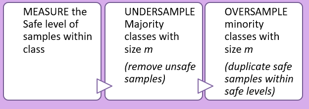

After measuring the safe levels of the samples per each class, th undersampling of the majority classes is performed by removing the most unsafe examples until a desired class cardinality is obtained. In this way, the undersampling process is focused on the examples lying closely to minority examples or inside their regions. The oversampling of minority classes is performed by dplicating the safest examples first, enhancing the representation of clear minority concepts. The final size of the resampled dataset has $m$ samples for each class. Size $m$ is computed using equation 3. SOUP provides not only a dataset with a balanced class distribution, but also with a reasonable size.

\begin{equation} m = mean \big(\max(N_{i_{MIN}}), \min(M_{i_{MAJ}}) \big) \tag{3} \end{equation}

where $m$ is the final size of the all classes, $N_{i_{MIN}}$ refers to the sizes of all minority classes, and $M_{i_{MAJ}}$ refers to the sizes of all the majority class.

### Simulations

```python
# !pip install multi_imbalance
```

```python
from multi_imbalance.resampling.soup import SOUP
```

The **multi_imbalance** library contains the implementation of SOUP and other resampling methods for multi-imbalance problems.

The SOUP parameters were the following:

```
param k:
    number of neighbors, default is 7.
param shuffle:
    bool - output will be shuffled
param maj_int_min:
    dict {'maj': majority class labels, 'min': minority class labels}
```

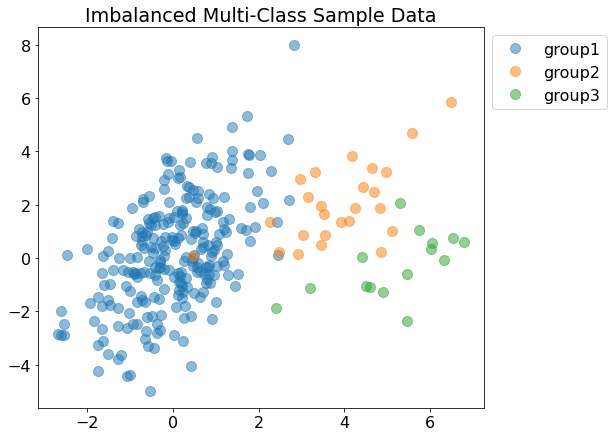

```python
# Generate data based on the above parameters
n_data = [250, 25, 15]
# 3 groups in 2D
d_means = {'group1': [0, 0],
           'group2': [4, 2],
           'group3': [6, 0],
          }
d_covs = {'group1': [[1, 1],
                        [1, 4]],
          'group2': [[2, 1],
                        [2, 3]],
          'group3': [[2, 1],
                        [2, 2]]
         }

# Generate data based on the above parameters
l = []
plt.figure(figsize=(8,7))
for group, n in zip(d_means.keys(), n_data):
    arr = np.random.multivariate_normal(d_means[group], d_covs[group], n)
    df_tmp = pd.DataFrame(arr)
    df_tmp['label'] = group
    l.append(df_tmp)
    plt.plot(df_tmp[0], df_tmp[1], 'o', label=group, markersize=10, alpha=0.5)

plt.legend(bbox_to_anchor=(1,1))
plt.title('Imbalanced Multi-Class Sample Data')
plt.show()
```

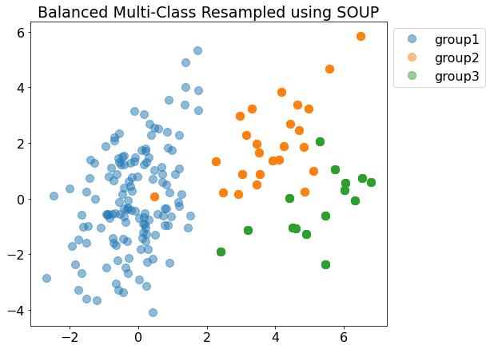

```python
df = pd.concat([l[0],l[1],l[2]])
df.head()

X = df[[0,1]]
y = df[['label']]

# from multi_imbalance.utils.plot import plot_visual_comparision_datasets
k = 7 #default n neighbors to look at
soup = SOUP( k=10, maj_int_min={
        'maj': ['group1'],
        'min': ['group2','group3']
    })

X_train_res, y_train_res = soup.fit_resample(np.copy(X), np.copy(y))

df = pd.DataFrame(X_train_res)

df['label'] = y_train_res

plt.figure(figsize=(8,7))

for group in np.unique(y_train_res):
    df_group = df[df['label']==group]
    plt.plot(df_group[0], df_group[1], 'o', label=group, markersize=10, alpha=0.5)

plt.legend(bbox_to_anchor=(1,1))
plt.title('Balanced Multi-Class Resampled using SOUP')
plt.show()
```

```python
# calculating the size m for each class
m = np.mean([250, 25])
m
```

```
137.5
```

```python
# Checking the number of samples for each class after resampling
df.label.value_counts()
```

```
group1    137
group2    137
group3    137
Name: label, dtype: int64
```

The original dataset has 250 samples for group1, 25 samples for group2, and 15 samples for group3. After resampling using SOUP, the minority classes group2 and group3 and majority class group1 are balanced with 137 sample size for each class.

# ML Implementation: The Glass Multi-class Problem

To evaluate the performance of the SOUP resampling method, the traditional SMOTE resampling will be implemented as well. The dataset that will be used in this project is from UCI. The Glass Dataset contains 214 rows with 11 attributes. The objective for this problem is to predict the type of glass based on the refractive index and the concentrations of different elements in the glass. The link of the dataset is found [here](https://archive.ics.uci.edu/ml/datasets/glass+identification).

## Methodology

Figure 3. Step by step process for the Glass Multi-Class Problem

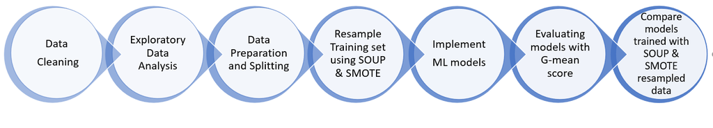

```python
from PIL import Image

image = Image.open('Capture.PNG')
image.show()
```

## Data Description

#### Attributes

1. Id number: 1 to 214
2. RI: refractive index
3. Na: Sodium (unit measurement: weight percent in corresponding oxide, as are attributes 4-10)
4. Mg: Magnesium
5. Al: Aluminum
6. Si: Silicon
7. K: Potassium
8. Ca: Calcium
9. Ba: Barium
10. Fe: Iron
11. Type of glass: (class attribute)
    - 1 : building_windows_float_processed
    - 2 : building_windows_non_float_processed
    - 3 : vehicle_windows_float_processed
    - 4 : vehicle_windows_non_float_processed (none in this database)
    - 5 : containers
    - 6 : tableware
    - 7 : headlamps

```python
data = pd.read_csv('glass.data', header=None)
```

```python
data.columns = ['id_num', 'RI', 'Na', 'Mg', 'Al', 'Si', 'K', 'Ca', 'Ba', 'Fe','glass_type' ]
```

```python
data.head(2)
```

|  | id_num | RI | Na | Mg | Al | Si | K | Ca | Ba | Fe | glass_type |
| --- | --- | --- | --- | --- | --- | --- | --- | --- | --- | --- | --- |
| 0 | 1 | 1.52101 | 13.64 | 4.49 | 1.10 | 71.78 | 0.06 | 8.75 | 0.0 | 0.0 | 1 |
| 1 | 2 | 1.51761 | 13.89 | 3.60 | 1.36 | 72.73 | 0.48 | 7.83 | 0.0 | 0.0 | 1 |

## EDA

```python
data.info()
```

```
<class 'pandas.core.frame.DataFrame'>
RangeIndex: 214 entries, 0 to 213
Data columns (total 11 columns):
 #   Column      Non-Null Count  Dtype
---  ------      --------------  -----
 0   id_num      214 non-null    int64
 1   RI          214 non-null    float64
 2   Na          214 non-null    float64
 3   Mg          214 non-null    float64
 4   Al          214 non-null    float64
 5   Si          214 non-null    float64
 6   K           214 non-null    float64
 7   Ca          214 non-null    float64
 8   Ba          214 non-null    float64
 9   Fe          214 non-null    float64
 10  glass_type  214 non-null    int64
dtypes: float64(9), int64(2)
memory usage: 18.5 KB
```

No null values for each attribute.

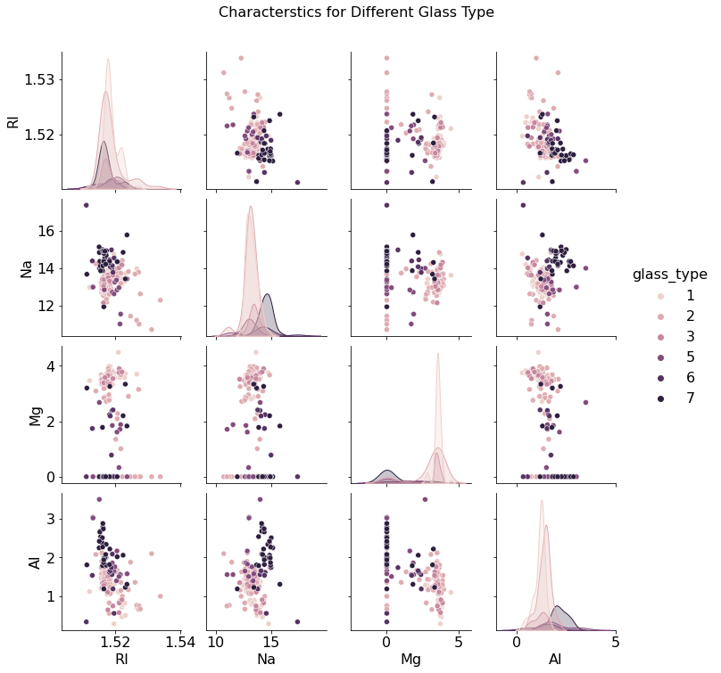

```python
# Compare smoker vs non-smoker
sns.pairplot(data, vars=['RI', 'Na', 'Mg', 'Al'], hue='glass_type')
plt.suptitle('Characterstics for Different Glass Type', size=16, y=1.05);
```

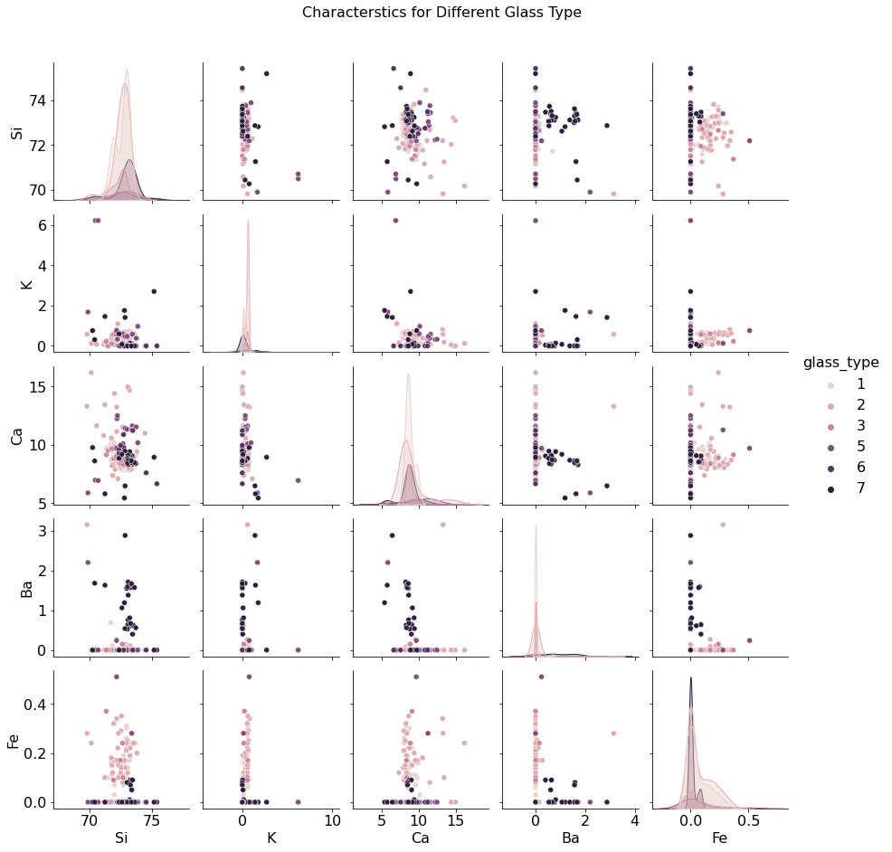

```python
sns.pairplot(data, vars=['Si', 'K', 'Ca', 'Ba', 'Fe'], hue='glass_type')
plt.suptitle('Characterstics for Different Glass Type', size=16, y=1.05);
```

Overlapping samples are observed from different classes for all features.

```python
from multi_imbalance.utils.plot import plot_cardinality_and_2d_data
seed = 12
```

```python
# Preparing our features and labels
X = data.drop(['id_num','glass_type'], axis=1)
y = data['glass_type']
```

```python
data['glass_type'].value_counts()
```

```
2    76
1    70
7    29
3    17
5    13
6     9
Name: glass_type, dtype: int64
```

The dataset has no type 4 glass. Overall, we have 6 classes.

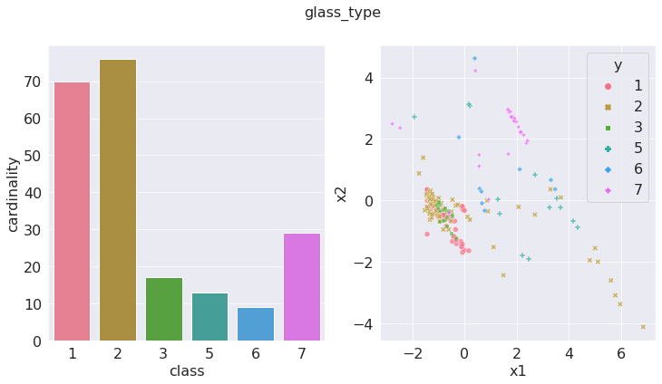

```python
plot_cardinality_and_2d_data(X, y, 'glass_type')
```

**Insights:**

Type 1 and 2 glasses are the majority classes. There are 76 samples of type 2 glass and 70 samples of type 1 glass. Types 3,5,6 and 7 are the minority classes. There are only 17 samples for type 3 glass, while 13, 9, and 29 samples for types 5, 6 and 7 glasses, respectively.

Projection of the samples when Principal Components Analysis (PCA) was applied on the dataset is shown above. The 1st and 2nd principal components are used for the axes. Interestingly, types 1, 2, 3 glasses are overlapping in the plot.

## Results and Discussion

This section shows the implementation of SOUP on the imbalance dataset. There are 8 machine learning classification models used in this problem. To evaluate the performance of SOUP, we compare the G-mean score of the models using the original dataset and when the dataset is resampled using SOUP and SMOTE.

In order to prepare data for training, we will split the data for train and test subsets and normalize it. For both operations, we will use tools available in sklearn.

### Training

The training will be performed using different ML classifiers from sklearn library. For simplicity, the default parameters are used for all classifiers.

```python
from sklearn.model_selection import train_test_split
from sklearn.preprocessing import StandardScaler

X_train, X_test, y_train, y_test = train_test_split(X, y, test_size=0.30, stratify=y, random_state=seed)
X_train.shape, X_test.shape
```

```
((149, 9), (65, 9))
```

```python
np.unique(y_train, return_counts=True)
```

```
(array([1, 2, 3, 5, 6, 7]), array([49, 53, 12,  9,  6, 20]))
```

Test size is 30% of the overall dataset. The dataset is also stratified to retain the original distribution of the test set.

```python
scaler = StandardScaler()
scaler.fit(X_train)

X_train = scaler.transform(X_train)
X_test = scaler.transform(X_test)

scorer = make_scorer(gmean_score)
```

```python
models_dict = {
    'KNeighborsClassifier': KNeighborsClassifier(),
    'LogisticRegressor': LogisticRegression(multi_class='multinomial'),
    'LinearSVM': SVC(kernel='linear', decision_function_shape='ovo'),
    'RBFSVM': SVC(kernel='rbf', decision_function_shape='ovo'),
    'GaussianNB': GaussianNB(),
    'RandomForestClassifier': RandomForestClassifier(random_state=11),
    'DecisionTreeClassifier': DecisionTreeClassifier(random_state=11),
    'GradientBoostingClassifier': GradientBoostingClassifier(random_state=11)
}
```

To evaluate predictions to multi-imbalanced class we apply generalized G-mean of sensitives of each class: $$ gmean = (\Pi_{i=1}^n sensitivity_i)^{\frac{1}{n}}$$

### No Resampling

```python
# budget automl

res_orig = {}

# log start time
total_start = time.time()

for model_name, model in tqdm(models_dict.items()):

    start_time = time.time() # for logging run times
    kfold = KFold(n_splits=3, random_state=seed, shuffle=True)
    cv_scores = cross_val_score(estimator=model, X=X_train, y=y_train,
                                scoring=scorer, cv=kfold, n_jobs=-1)
    average_cv_score = np.mean(cv_scores)
    #retrain again
    model.fit(X_train,y_train)
    y_pred = model.predict(X_test)
    gmean = gmean_score(y_test, y_pred, correction=0.001)

    end_time = time.time() # for logging run times

    res_orig[model_name] = {
        'ave_train_g_mean': average_cv_score*100,
        'ave_val_g_mean': gmean* 100,
        'run_time': end_time - start_time
    }

# log end time
total_end = time.time()
elapsed = total_end - total_start
print(f"Report Generated in {elapsed:.2f} seconds")
res_orig = pd.DataFrame(res_orig).T
display(res_orig)
```

```
Report Generated in 4.06 seconds
```

|  | ave_train_g_mean | ave_val_g_mean | run_time |
| --- | --- | --- | --- |
| KNeighborsClassifier | 16.048306 | 23.227538 | 1.251217 |
| LogisticRegressor | 17.097252 | 21.103619 | 0.101444 |
| LinearSVM | 12.603026 | 19.775643 | 0.031746 |
| RBFSVM | 11.076042 | 22.364964 | 0.037348 |
| GaussianNB | 22.642043 | 42.040732 | 0.029887 |
| RandomForestClassifier | 51.561429 | 57.802565 | 0.506145 |
| DecisionTreeClassifier | 43.456184 | 57.032664 | 0.017003 |
| GradientBoostingClassifier | 42.197371 | 54.084549 | 2.067853 |

### Resampling using SOUP

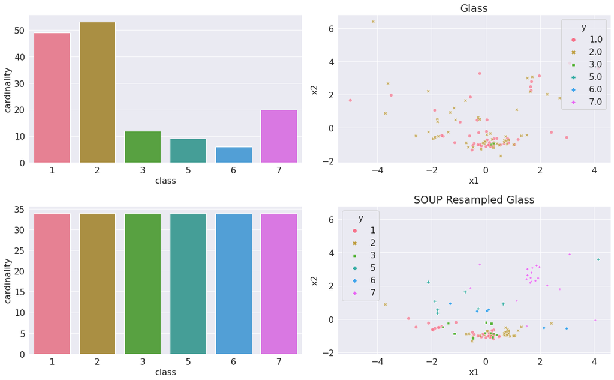

```python
from multi_imbalance.utils.plot import plot_visual_comparision_datasets
k = 7 #default n neighbors to look at
soup = SOUP(k=7, maj_int_min={
        'maj': [2,1],
        'min': [3,5,6,7]
    })


X_train_res, y_train_res = soup.fit_resample(np.copy(X_train), np.copy(y_train))
plot_visual_comparision_datasets(X_train, y_train, X_train_res, y_train_res,
                                 'Glass', 'SOUP Resampled Glass')
plt.tight_layout()
plt.savefig('SOUP_fig.png', dpi=300)
```

The dataset for training is now balanced when we applied SOUP. Using first and second principal components when we project our training samples is seen above. We can see more samples but less overlapping samples.

```python
np.unique(y_train_res, return_counts=True)
```

```
(array([1, 2, 3, 5, 6, 7]), array([34, 34, 34, 34, 34, 34]))
```

```python
# budget automl

res_oversampled = {}

# log start time
total_start = time.time()

for model_name, model in tqdm(models_dict.items()):

    start_time = time.time() # for logging run times
    kfold = KFold(n_splits=3, random_state=seed, shuffle=True)
    cv_scores = cross_val_score(estimator=model, X=X_train_res, y=y_train_res,
                                scoring=scorer, cv=kfold, n_jobs=-1)
    average_cv_score = np.mean(cv_scores)
    #retrain again
    model.fit(X_train_res,y_train_res)
    y_pred = model.predict(X_test)
    gmean = gmean_score(y_test, y_pred, correction=0.001)

    end_time = time.time() # for logging run times

    res_oversampled[model_name] = {
        'ave_train_g_mean': average_cv_score*100,
        'ave_val_g_mean': gmean* 100,
        'run_time': end_time - start_time
    }

# log end time
total_end = time.time()
elapsed = total_end - total_start
print(f"Report Generated in {elapsed:.2f} seconds")
res_oversampled_soup = pd.DataFrame(res_oversampled).T
display(res_oversampled_soup)
```

```
Report Generated in 3.07 seconds
```

|  | ave_train_g_mean | ave_val_g_mean | run_time |
| --- | --- | --- | --- |
| KNeighborsClassifier | 78.437595 | 58.053349 | 0.040069 |
| LogisticRegressor | 82.068870 | 79.228835 | 0.268540 |
| LinearSVM | 86.065010 | 70.654719 | 0.026165 |
| RBFSVM | 82.803086 | 61.476664 | 0.034506 |
| GaussianNB | 55.079302 | 24.006137 | 0.015749 |
| RandomForestClassifier | 90.829555 | 62.946199 | 0.494436 |
| DecisionTreeClassifier | 87.590148 | 47.863655 | 0.019186 |
| GradientBoostingClassifier | 92.573080 | 59.999328 | 2.166126 |

### Resampling using SMOTE

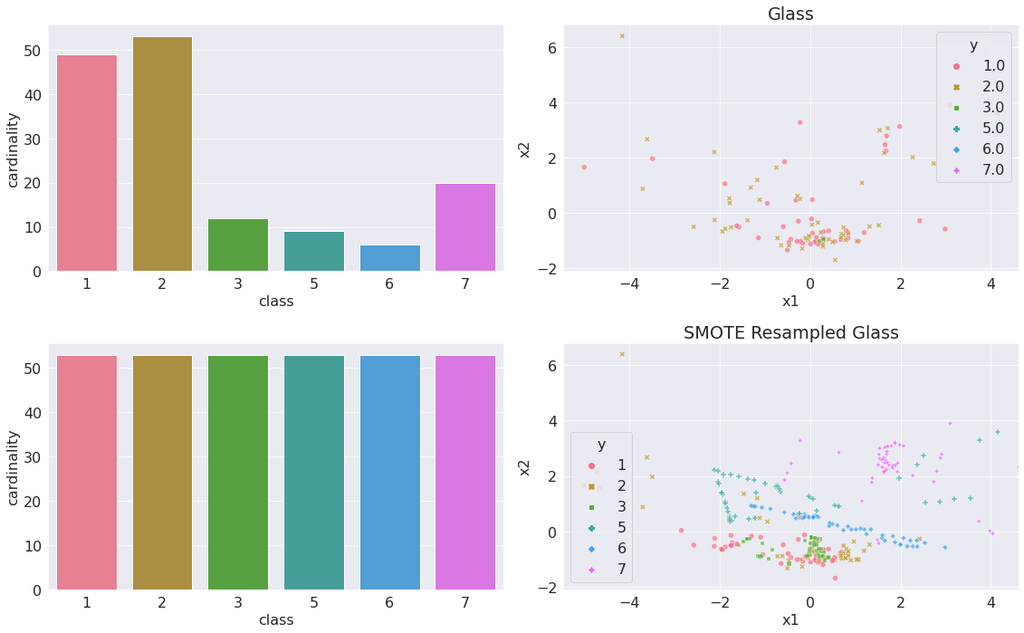

```python
# transform the dataset
oversample = SMOTE(random_state= seed)
X_smote, y_smote = oversample.fit_resample(np.copy(X_train), np.copy(y_train))

# summarize distribution
plot_visual_comparision_datasets(X_train, y_train, X_smote, y_smote,
                                 'Glass', 'SMOTE Resampled Glass')
plt.tight_layout()
plt.savefig('SMOTE_fig.png', dpi=300)
```

The dataset for training is now balanced. Using first and second principal components when we project our training samples is seen above. We can see more samples but borderlines samples are still retained.

```python
np.unique(y_smote, return_counts=True)
```

```
(array([1, 2, 3, 5, 6, 7]), array([53, 53, 53, 53, 53, 53]))
```

```python
# budget automl

res_oversampled = {}

# log start time
total_start = time.time()

for model_name, model in tqdm(models_dict.items()):

    start_time = time.time() # for logging run times
    kfold = KFold(n_splits=3, random_state=seed, shuffle=True)
    cv_scores = cross_val_score(estimator=model, X=X_smote, y=y_smote,
                                scoring=scorer, cv=kfold, n_jobs=-1)
    average_cv_score = np.mean(cv_scores)
    #retrain again
    model.fit(X_smote,y_smote)
    y_pred = model.predict(X_test)
    gmean = gmean_score(y_test, y_pred, correction=0.001)

    end_time = time.time() # for logging run times

    res_oversampled[model_name] = {
        'ave_train_g_mean': average_cv_score*100,
        'ave_val_g_mean': gmean* 100,
        'run_time': end_time - start_time
    }

# log end time
total_end = time.time()
elapsed = total_end - total_start
print(f"Report Generated in {elapsed:.2f} seconds")
res_oversampled_smote = pd.DataFrame(res_oversampled).T
display(res_oversampled_smote)
```

```
Report Generated in 3.60 seconds
```

|  | ave_train_g_mean | ave_val_g_mean | run_time |
| --- | --- | --- | --- |
| KNeighborsClassifier | 75.849150 | 63.611232 | 0.043990 |
| LogisticRegressor | 76.420436 | 70.158327 | 0.097063 |
| LinearSVM | 77.314739 | 65.497734 | 0.041980 |
| RBFSVM | 75.363601 | 65.497734 | 0.047326 |
| GaussianNB | 57.217085 | 56.671165 | 0.023067 |
| RandomForestClassifier | 88.439869 | 64.299154 | 0.577020 |
| DecisionTreeClassifier | 81.932130 | 53.540824 | 0.021785 |
| GradientBoostingClassifier | 86.360133 | 50.362829 | 2.738000 |

```python
df = pd.DataFrame(res_orig['ave_val_g_mean'])
df.columns = ['gmean_test_original']

df['gmean_test_SOUP'] = res_oversampled_soup['ave_val_g_mean']
df['gmean_test_SMOTE'] = res_oversampled_smote['ave_val_g_mean']
df
```

|  | gmean_test_original | gmean_test_SOUP | gmean_test_SMOTE |
| --- | --- | --- | --- |
| KNeighborsClassifier | 23.227538 | 58.053349 | 63.611232 |
| LogisticRegressor | 21.103619 | 79.228835 | 70.158327 |
| LinearSVM | 19.775643 | 70.654719 | 65.497734 |
| RBFSVM | 22.364964 | 61.476664 | 65.497734 |
| GaussianNB | 42.040732 | 24.006137 | 56.671165 |
| RandomForestClassifier | 57.802565 | 62.946199 | 64.299154 |
| DecisionTreeClassifier | 57.032664 | 47.863655 | 53.540824 |
| GradientBoostingClassifier | 54.084549 | 59.999328 | 50.362829 |

```python
X.columns
```

```
Index(['RI', 'Na', 'Mg', 'Al', 'Si', 'K', 'Ca', 'Ba', 'Fe'], dtype='object')
```

```python
best_model = LogisticRegression(multi_class='multinomial')
kfold = KFold(n_splits=3, random_state=seed, shuffle=True)
cv_scores = cross_val_score(estimator=best_model, X=X_train_res, y=y_train_res,
                            scoring=scorer, cv=kfold, n_jobs=-1)
average_cv_score = np.mean(cv_scores)
#retrain again
feature_names = X.columns
best_model.fit(X_train_res,y_train_res)
y_pred = best_model.predict(X_test)

best_model.classes_
```

```
array([1, 2, 3, 5, 6, 7])
```

```python
def get_most_important_feature(idx, name, feature, model):
    coefs = model.coef_[idx]
    coefs_count = len(coefs)
    abs_coefs = np.abs(coefs)
    fig, ax = plt.subplots(figsize=(6,5))
    ax.barh(np.arange(coefs_count), sorted(abs_coefs))

    ax.set_yticks(np.arange(coefs_count))
    ax.set_yticklabels(feature[np.argsort(abs_coefs)])
    most_imp = np.abs(coefs).argmax()
    print('For', name, 'the Top predictor is',feature[most_imp]+
          ' using the model '+ str(model)+'.')
```

```
For Type 1 Glass the Top predictor is RI using the model LogisticRegression(multi_class='multinomial').
```

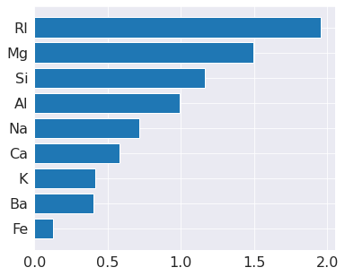

```python
get_most_important_feature(0, 'Type 1 Glass', feature_names, best_model)
```

```
For Type 2 Glass the Top predictor is Ca using the model LogisticRegression(multi_class='multinomial').
```

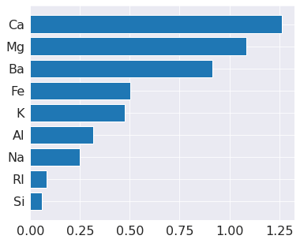

```python
get_most_important_feature(1, 'Type 2 Glass', feature_names, best_model)
```

```
For Type 3 Glass the Top predictor is RI using the model LogisticRegression(multi_class='multinomial').
```

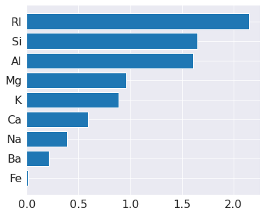

```python
get_most_important_feature(2, 'Type 3 Glass', feature_names, best_model)
```

```
For Type 5 Glass the Top predictor is Na using the model LogisticRegression(multi_class='multinomial').
```

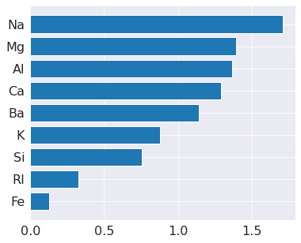

```python
get_most_important_feature(3, 'Type 5 Glass', feature_names, best_model)
```

```
For Type 6 Glass the Top predictor is Na using the model LogisticRegression(multi_class='multinomial').
```

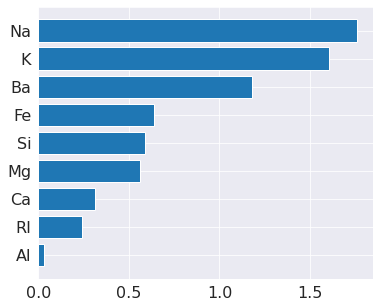

```python
get_most_important_feature(4, 'Type 6 Glass', feature_names, best_model)
```

```
For Type 7 Glass the Top predictor is Mg using the model LogisticRegression(multi_class='multinomial').
```

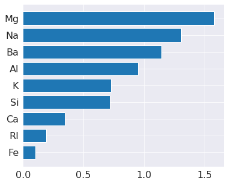

```python
get_most_important_feature(5, 'Type 7 Glass', feature_names, best_model)
```

The dataset is split into 70/30 for training and test set, respectively. 3-Fold cross-validation is used in the training the models. The classifiers used are KNN, Logistic Regressor, Linear SVM, RBF SVM, Gaussian Naive Bayes, Random Forest, Decision Trees, and Gradient Boosting classifiers.

Originally, the training data is composed of 49 and 53 samples for type 1 and 2 glasses. There are only 12, 9, 6, 20 samples for type 3, 5, 6, 7 glasses. After resampling with SOUP, all classes have 34 samples. However, resampling the original training set with SMOTE still gives a balance dataset with 53 samples for each class.

Using only the default parameters for our 8 models, our best model for this problem is the Logistic Regression. When the model is trained on the SOUP resampled dataset, the G-mean score is 79.2%. Training this model using SMOTE resampled dataset gives a G-mean score of 70.2%. Resampling the original data signficantly improves Logistic regression model. G-mean score is only 21.1% if the model is trained on the original data.

Linear SVM trained from the resampled SOUP dataset is the second best performing model with a G-mean score of 70.7%. If we trained a default Linear SVM with dataset resampled from SMOTE, the G-mean score is around 65.5%. However, GaussianNB and DecisionTree classifiers did not improve when they are trained from the dataset resampled with SOUP.

Looking at the best model that is trained from the resampled data using SOUP, Logistic Regressor, the most important feature for each class is different. For type 1 glass, the most important predictor is the Refractive index. For type 2 glass, the most important is the Calcium concentration of the glass. The refractive index is also the most important feature for Type 3 glass. For types 5 and 6, the most important features are Sodium concentration while Magnesium concentration for type 7 glass.

## Conclusion

SOUP is a hybrid resampling technique that considers the mutual relations between classes. It uses safety coefficients that can be efficiently exploited in resampling techniques to improve classifiers. In the Glass Prediction Problem, the original samples have overlapping features when projected. There is also an imbalance between classes. This project shows that SOUP is an effective resampling technique for this case since overlapping samples which can be *rare, borderlines or outliers* will be removed before resampling. This enhances the representation of each class.

However, it is recommended to apply the SOUP technique to other multi-class imbalance data and compare it with other resampling methods. In this project, SOUP is only compared to SMOTE.

## Reference

1. Janicka, M., Lango, M. and Stefanowski, J., 2019. Using Information on Class Interrelations to Improve Classification of Multiclass Imbalanced Data: A New Resampling Algorithm. International Journal of Applied Mathematics and Computer Science, 29(4), pp.769-781.
2. https://github.com/damian-horna/multi-imbalance